# PC GP01 02 C

## Percussion (2020-10-26)

- Large male pig: 73 kg (150 lb)  
  The urinary catheter was installed by percutaneous puncture of the bladder.
- 4 hits at 35 deg:
1. Hit 0: 0.09 atm with big bubble
2. Hit 1: 5.47 atm, ICP at 30 mmHg at 16:50 pm
3. Hit 2: 6.18 atm, ICP at 24 mmHg at 16:52 pm
4. Hit 3: 6.65 atm, ICP at 29 mmHg at 16:53 pm
5. Hit 4: 6.58 atm, ICP at 30 mmHg at 16:54 pm

Study ended at 13:00 pm (next day - 20h).

## Cooling

Started at 17:02 pm.  
Brain temperature was 36.4 deg.  
Cooling unit failed around midnight, stayed around 37 deg and raised up to 38.8 deg in the morning.

## Cooling set up

1st target = -10 deg (VT outlet temp)  
Flow rate = 60 SLPM  
2nd target = 34.0 deg (brain temp to cool down to)  
Maintenance time = 960 min once brain reached 33 deg  
3rd target temperature = 36 deg (rewarm target)  
Rewarm rate = 0.25 deg/h

| Scan time | Description |
| --- | --- |
| 16:21 | Baseline |
| 17:11 | 15 min post |
| 17:25 | 30 min post |
| 17:56 | 60 min post |
| 18:56 | 2h post |
| 19:56 | 3h post |
| 21:00 | 4h post |
| 23:00 | 6h post |
| 01:00 | 8h post |
| 05:00 | 12h post |
| 09:00 | 16h post |
| 13:00 | 20h post |

## Plots

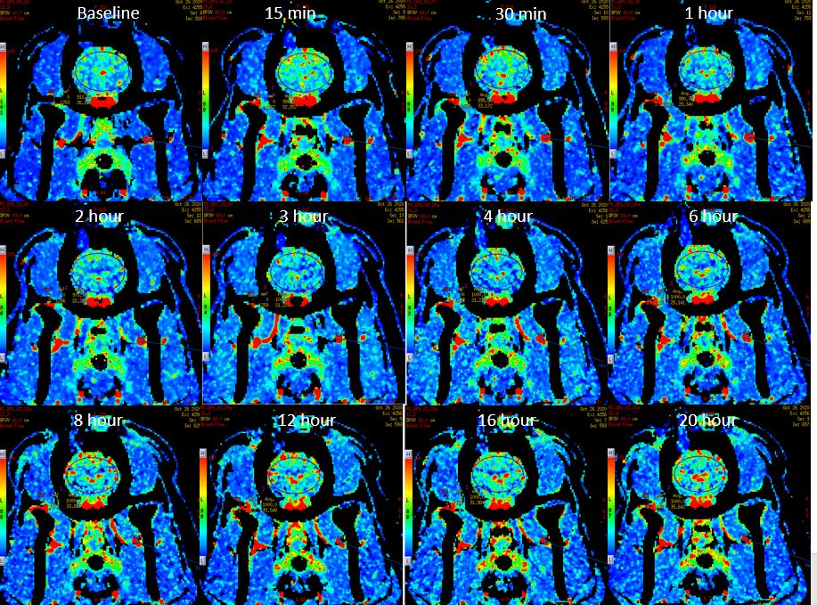

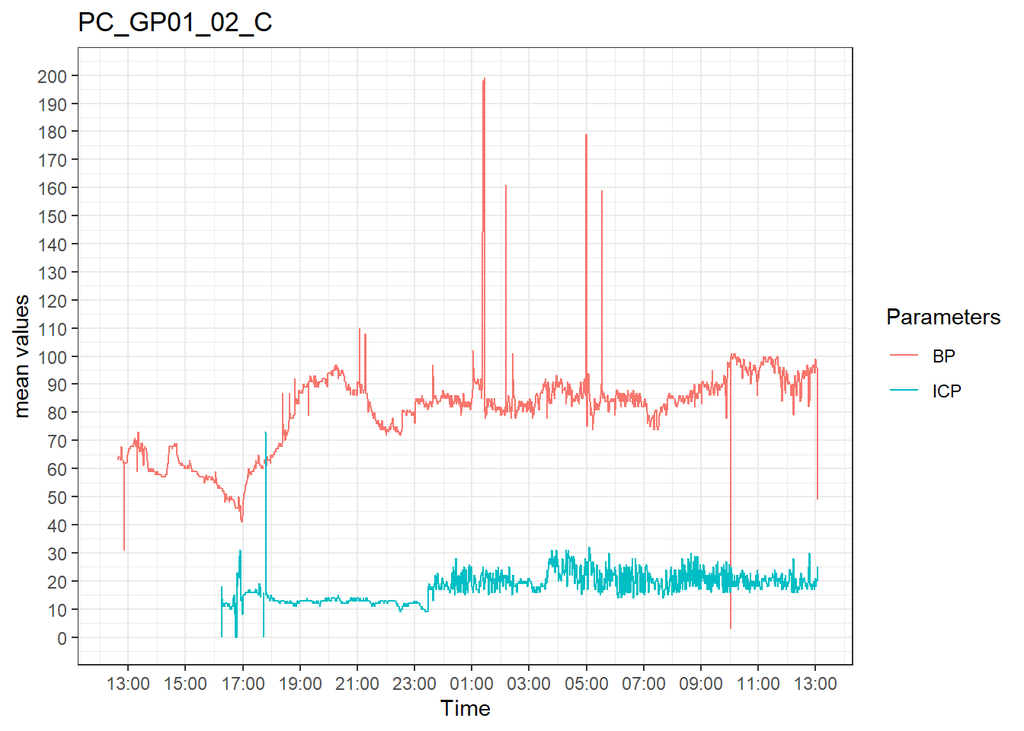

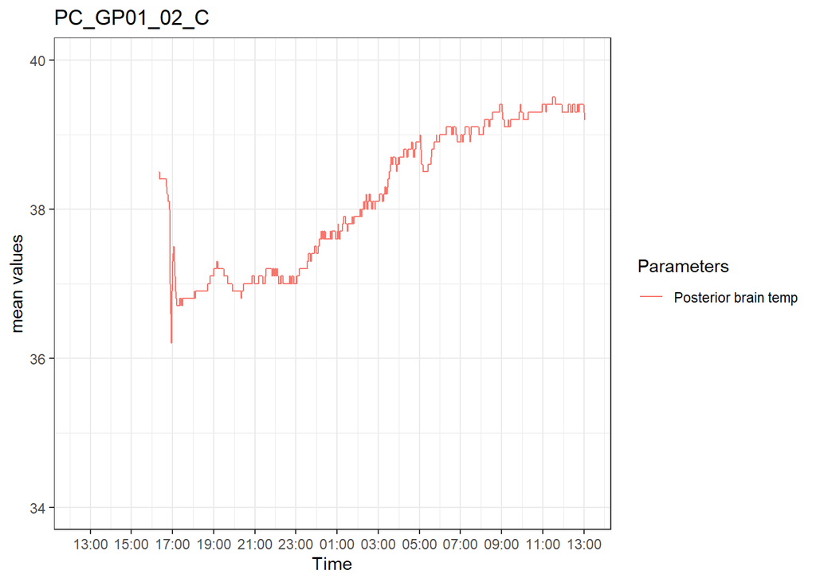

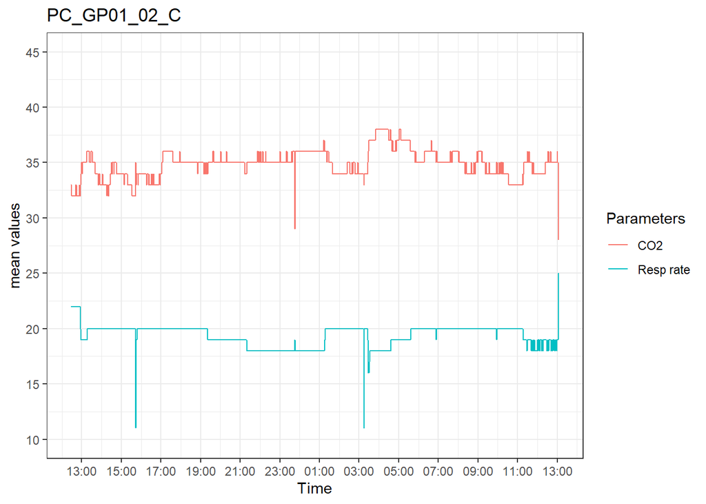

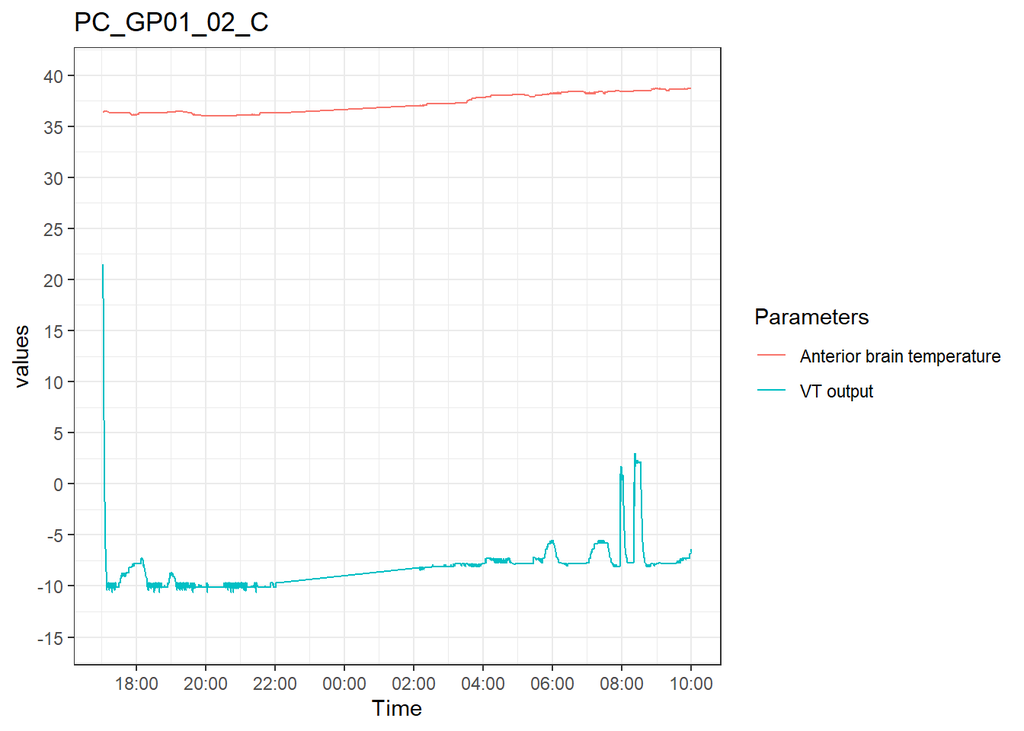

## TTC

No TTC result